# R Notebook

```r
library(tidyverse)
library(sf)
library(scales)
```

```r
burglaries_2023 <- read_csv("data/burglaries_2023.csv")
census <- read_csv("data/census.csv")
DC = read_sf(dsn = "data/DC", layer = "DC")
```

```r
burglaries_2023 %>% head()
```

| primary_key | incident_number | report_type | report_type_description | incident_status_code | incident_status_description | investigation_status | incident_occurred | incident_reported | incident_location | latitude | longitude | zip_code | location_code | location_description | offense_number | offense_nibrs | offense_description | weapon_primary | weapon_description | victim_number | domestic_related | victim_type | victim_description | mapped_location | victim_gender | victim_race | victim_ethnicity | victim_county_resident |
| --- | --- | --- | --- | --- | --- | --- | --- | --- | --- | --- | --- | --- | --- | --- | --- | --- | --- | --- | --- | --- | --- | --- | --- | --- | --- | --- | --- | --- |
| 20230470925_32 | 20230470925 | D | DISPATCHED | O | OPEN | Open | 2023-08-10 18:04:00 | 2023-08-10 18:58:00 | SHEPHERD HILLS DR | 36.300 | -86.690 | NA | 22 | RESIDENCE, HOME | 3 | 220 | BURGLARY - AGGRAVATED | 01 | HANDGUN | 2 | TRUE | I | INDIVIDUAL (18 AND OVER) | NA | F | B | Non-Hispanic | RESIDENT |
| 20230227104_12 | 20230227104 | D | DISPATCHED | O | OPEN | Open | 2023-04-17 18:00:00 | 2023-04-18 12:49:00 | NA | NA | NA | NA | 22 | RESIDENCE, HOME | 1 | 220 | BURGLARY- AGGRAVATED | 09 | PERSONAL (HANDS) | 2 | FALSE | I | INDIVIDUAL (18 AND OVER) | NA | F | B | Non-Hispanic | NON RESIDENT |
| 20230453427_11 | 20230453427 | D | DISPATCHED | O | OPEN | Open | 2023-08-02 23:58:00 | 2023-08-02 23:58:00 | WHITE BRIDGE PKE | 36.160 | -86.770 | NA | 90 | APARTMENT | 1 | 220 | BURGLARY - AGGRAVATED | 17 | NONE | 1 | FALSE | I | INDIVIDUAL (18 AND OVER) | NA | M | B | Non-Hispanic | RESIDENT |
| 20230453427_12 | 20230453427 | D | DISPATCHED | O | OPEN | Open | 2023-08-02 23:58:00 | 2023-08-02 23:58:00 | WHITE BRIDGE PKE | 36.160 | -86.770 | NA | 90 | APARTMENT | 1 | 220 | BURGLARY - AGGRAVATED | 17 | NONE | 2 | FALSE | I | INDIVIDUAL (18 AND OVER) | NA | F | B | Non-Hispanic | RESIDENT |
| 20230430933_11 | 20230430933 | D | DISPATCHED | O | OPEN | Open | 2023-07-21 16:00:00 | 2023-07-22 23:35:00 | TUPELO | 36.040 | -86.620 | NA | 22 | RESIDENCE, HOME | 1 | 220 | BURGLARY- AGGRAVATED | 17 | NONE | 1 | FALSE | I | INDIVIDUAL (18 AND OVER) | NA | F | B | Non-Hispanic | RESIDENT |
| 20230211343_11 | 20230211343 | D | DISPATCHED | A | CLEARED BY ARREST | Closed | 2023-04-10 22:00:00 | 2023-04-10 23:08:00 | 585 585 | 36.283 | -86.796 | 37189 | 22 | RESIDENCE, HOME | 1 | 220 | BURGLARY- AGGRAVATED | 09 | PERSONAL (HANDS) | 1 | TRUE | I | INDIVIDUAL (18 AND OVER) | NA | F | B | Non-Hispanic | RESIDENT |

```r
census %>% head()
```

| NAME | state | county | tract | population | median_income |
| --- | --- | --- | --- | --- | --- |
| Census Tract 190.04, Davidson County, Tennessee | 47 | 037 | 019004 | 4470 | 44001 |
| Census Tract 190.07, Davidson County, Tennessee | 47 | 037 | 019007 | 2904 | 48485 |
| Census Tract 190.08, Davidson County, Tennessee | 47 | 037 | 019008 | 6005 | 50512 |
| Census Tract 191.05, Davidson County, Tennessee | 47 | 037 | 019105 | 5707 | 48271 |
| Census Tract 191.06, Davidson County, Tennessee | 47 | 037 | 019106 | 4336 | 65323 |
| Census Tract 191.08, Davidson County, Tennessee | 47 | 037 | 019108 | 3478 | 34893 |

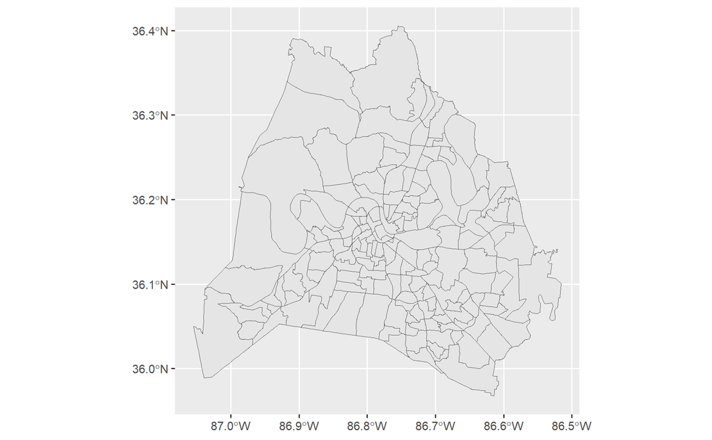

```r
DC %>%
  ggplot() +
  geom_sf()
```

```r
burglaries_geo <- st_as_sf(burglaries_2023 %>%  drop_na(latitude),
         coords = c('longitude', 'latitude'),
         crs = st_crs(DC)
         )
```

```r
burglaries_tracts <- st_join(burglaries_geo, DC, join = st_within)
burglaries_full <- merge(census, burglaries_tracts, by.x = "tract", by.y = "TRACTCE", all = FALSE)
```

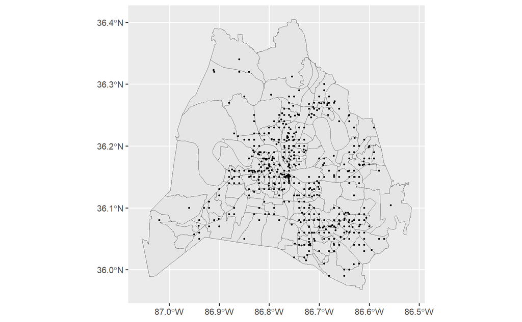

```r
ggplot(DC) +
  geom_sf() +
  geom_sf(data = burglaries_full$geometry, size = 0.5)
```

Part 2 - Exploratory Analysis Perform some exploraty analysis on your prepared dataset.

Aggregate the data by census tract. Warning: each incident can appear multiple times if there are multiple victims, so be sure that you aren’t double-counting any incidents.

Which census tract had the highest number of burglaries? Which census tract had the highest number of burglaries per 1000 residents?

```r
incidents_per_tract <- burglaries_full %>%
  st_drop_geometry() %>%
  group_by(tract) %>%
  summarize(num_incidents_per_tract = n_distinct(incident_number)) %>%
  arrange(desc(num_incidents_per_tract))
sum(incidents_per_tract$num_incidents_per_tract)
```

```
[1] 894
```

```r
incidents_per_tract
```

| tract | num_incidents_per_tract |
| --- | --- |
| 016000 | 39 |
| 011300 | 27 |
| 011001 | 26 |
| 014200 | 23 |
| 012701 | 18 |
| 019300 | 18 |
| 011900 | 17 |
| 010903 | 15 |
| 019108 | 14 |
| 013900 | 13 |

[output cut: 147 more lines]

```r
tract_pops <- burglaries_full %>%
  st_drop_geometry() %>%
  select(c(tract,population)) %>%
  distinct()
```

```r
incidents_per_thousand <- inner_join(incidents_per_tract,tract_pops, by="tract") %>%
  mutate(incidents_per_thousand_pop = num_incidents_per_tract/(population/1000)) %>%
  arrange(desc(incidents_per_thousand_pop)) %>%
  filter(is.finite(incidents_per_thousand_pop))

incidents_per_thousand_top10 <- incidents_per_thousand %>% head(10)

burglaries_full_top10tracts <- filter(burglaries_full, tract %in% incidents_per_thousand_top10$tract)

incidents_per_thousand
```

| tract | num_incidents_per_tract | population | incidents_per_thousand_pop |
| --- | --- | --- | --- |
| 016000 | 39 | 2570 | 15.1750973 |
| 014200 | 23 | 2072 | 11.1003861 |
| 013900 | 13 | 1720 | 7.5581395 |
| 014300 | 11 | 1617 | 6.8027211 |
| 011900 | 17 | 2746 | 6.1908230 |
| 012600 | 12 | 2152 | 5.5762082 |
| 019300 | 18 | 3498 | 5.1457976 |
| 011300 | 27 | 5980 | 4.5150502 |
| 015900 | 12 | 2876 | 4.1724618 |
| 014800 | 6 | 1454 | 4.1265475 |

[output cut: 145 more lines]

```r
incidents_per_thousand_top10
```

| tract | num_incidents_per_tract | population | incidents_per_thousand_pop |
| --- | --- | --- | --- |
| 016000 | 39 | 2570 | 15.175097 |
| 014200 | 23 | 2072 | 11.100386 |
| 013900 | 13 | 1720 | 7.558140 |
| 014300 | 11 | 1617 | 6.802721 |
| 011900 | 17 | 2746 | 6.190823 |
| 012600 | 12 | 2152 | 5.576208 |
| 019300 | 18 | 3498 | 5.145798 |
| 011300 | 27 | 5980 | 4.515050 |
| 015900 | 12 | 2876 | 4.172462 |
| 014800 | 6 | 1454 | 4.126547 |

```r
burglaries_full_top10tracts
```

| tract | NAME.x | state | county | population | median_income | primary_key | incident_number | report_type | report_type_description | incident_status_code | incident_status_description | investigation_status | incident_occurred | incident_reported | incident_location | zip_code | location_code | location_description | offense_number | offense_nibrs | offense_description | weapon_primary | weapon_description | victim_number | domestic_related | victim_type | victim_description | mapped_location | victim_gender | … |
| --- | --- | --- | --- | --- | --- | --- | --- | --- | --- | --- | --- | --- | --- | --- | --- | --- | --- | --- | --- | --- | --- | --- | --- | --- | --- | --- | --- | --- | --- | --- |
| 011300 | Census Tract 113, Davidson County, Tennessee | 47 | 037 | 5980 | 59107 | 20230551582_11 | 20230551582 | D | DISPATCHED | O | OPEN | Open | 2023-09-16 00:30:00 | 2023-09-16 02:34:00 | FERN AVE | NA | 22 | RESIDENCE, HOME | 1 | 220 | BURGLARY- AGGRAVATED | 17 | NONE | 1 | FALSE | I | INDIVIDUAL (18 AND OVER) | NA | M | … |
| 011300 | Census Tract 113, Davidson County, Tennessee | 47 | 037 | 5980 | 59107 | 20230582489_12 | 20230582489 | D | DISPATCHED | O | OPEN | Open | 2023-09-30 00:48:00 | 2023-09-30 02:46:00 | LUCILE ST | NA | 22 | RESIDENCE, HOME | 1 | 220 | BURGLARY - AGGRAVATED | 17 | NONE | 2 | FALSE | I | INDIVIDUAL (18 AND OVER) | NA | M | … |
| 011300 | Census Tract 113, Davidson County, Tennessee | 47 | 037 | 5980 | 59107 | 20230360888_11 | 20230360888 | D | DISPATCHED | O | OPEN | Open | 2023-06-20 18:00:00 | 2023-06-20 20:00:00 | LUTON ST | NA | 22 | RESIDENCE, HOME | 1 | 220 | BURGLARY- AGGRAVATED | 17 | NONE | 1 | TRUE | I | INDIVIDUAL (18 AND OVER) | NA | M | … |
| 011300 | Census Tract 113, Davidson County, Tennessee | 47 | 037 | 5980 | 59107 | 20230542873_11 | 20230542873 | D | DISPATCHED | O | OPEN | Open | 2023-09-04 00:00:00 | 2023-09-12 13:11:00 | EDWIN ST | NA | 22 | RESIDENCE, HOME | 1 | 220 | BURGLARY- AGGRAVATED | 17 | NONE | 1 | FALSE | B | BUSINESS | NA | NA | … |
| 011300 | Census Tract 113, Davidson County, Tennessee | 47 | 037 | 5980 | 59107 | 20230397020_11 | 20230397020 | D | DISPATCHED | O | OPEN | Open | 2023-07-06 06:15:00 | 2023-07-06 21:09:00 | LUTON ST | NA | 22 | RESIDENCE, HOME | 1 | 220 | BURGLARY- AGGRAVATED | 17 | NONE | 1 | FALSE | I | INDIVIDUAL (18 AND OVER) | NA | F | … |
| 011300 | Census Tract 113, Davidson County, Tennessee | 47 | 037 | 5980 | 59107 | 20230315677_11 | 20230315677 | D | DISPATCHED | A | CLEARED BY ARREST | Closed | 2023-05-30 13:12:00 | 2023-05-30 14:54:00 | & | 37207 | 90 | APARTMENT | 1 | 220 | BURGLARY - ESPECIALLY AGGRAVATED | 01 | HANDGUN | 1 | FALSE | I | INDIVIDUAL (18 AND OVER) | NA | F | … |
| 011300 | Census Tract 113, Davidson County, Tennessee | 47 | 037 | 5980 | 59107 | 20230054599_11 | 20230054599 | D | DISPATCHED | O | OPEN | Open | 2023-01-26 13:24:00 | 2023-01-26 14:06:00 | MARIE ST | NA | 22 | RESIDENCE, HOME | 1 | 220 | BURGLARY- AGGRAVATED | 09 | PERSONAL (HANDS) | 1 | FALSE | I | INDIVIDUAL (18 AND OVER) | NA | F | … |
| 011300 | Census Tract 113, Davidson County, Tennessee | 47 | 037 | 5980 | 59107 | 20230582477_11 | 20230582477 | D | DISPATCHED | O | OPEN | Open | 2023-09-30 00:00:00 | 2023-09-30 01:52:00 | STAINBACK AV | NA | 22 | RESIDENCE, HOME | 1 | 220 | BURGLARY- AGGRAVATED | 16 | Unarmed | 1 | FALSE | I | INDIVIDUAL (18 AND OVER) | NA | M | … |
| 011300 | Census Tract 113, Davidson County, Tennessee | 47 | 037 | 5980 | 59107 | 20230582489_14 | 20230582489 | D | DISPATCHED | O | OPEN | Open | 2023-09-30 00:48:00 | 2023-09-30 02:46:00 | LUCILE ST | NA | 22 | RESIDENCE, HOME | 1 | 220 | BURGLARY - AGGRAVATED | 17 | NONE | 4 | FALSE | B | BUSINESS | NA | NA | … |
| 011300 | Census Tract 113, Davidson County, Tennessee | 47 | 037 | 5980 | 59107 | 20230447392_11 | 20230447392 | T | NA | O | OPEN | Open | 2023-07-27 18:00:00 | 2023-07-31 08:34:00 | JONES AV | NA | 22 | RESIDENCE, HOME | 1 | 220 | BURGLARY- AGGRAVATED | 16 | Unarmed | 1 | FALSE | I | INDIVIDUAL (18 AND OVER) | NA | F | … |

[output cut: 219 more lines]

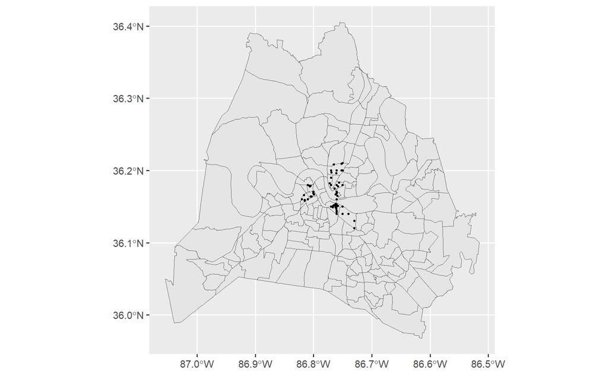

```r
ggplot(DC) +
  geom_sf() +
  geom_sf(data = burglaries_full_top10tracts$geometry, size = 0.5)
```

```r
burglaries_full_calc <- merge(x=burglaries_full,y=incidents_per_thousand,
             by=c("tract","population"), all.x=TRUE)
burglaries_full_calc <- burglaries_full_calc %>%
  filter(median_income>=0)
burglaries_full_calc <- merge(x=burglaries_full_calc, y=DC, by.x = "tract", by.y = "TRACTCE", all.x=TRUE)
burglaries_full_calc
```

| tract | population | NAME.x | state | county | median_income | primary_key | incident_number | report_type | report_type_description | incident_status_code | incident_status_description | investigation_status | incident_occurred | incident_reported | incident_location | zip_code | location_code | location_description | offense_number | offense_nibrs | offense_description | weapon_primary | weapon_description | victim_number | domestic_related | victim_type | victim_description | mapped_location | victim_gender | … |
| --- | --- | --- | --- | --- | --- | --- | --- | --- | --- | --- | --- | --- | --- | --- | --- | --- | --- | --- | --- | --- | --- | --- | --- | --- | --- | --- | --- | --- | --- | --- |
| 010103 | 2411 | Census Tract 101.03, Davidson County, Tennessee | 47 | 037 | 60000 | 20230486382_11 | 20230486382 | D | DISPATCHED | O | OPEN | Open | 2023-08-13 12:30:00 | 2023-08-17 14:22:00 | CLAY LICK | NA | 22 | RESIDENCE, HOME | 1 | 220 | BURGLARY- AGGRAVATED | 16 | Unarmed | 1 | FALSE | I | INDIVIDUAL (18 AND OVER) | NA | M | … |
| 010103 | 2411 | Census Tract 101.03, Davidson County, Tennessee | 47 | 037 | 60000 | 20230053195_11 | 20230053195 | D | DISPATCHED | O | OPEN | Open | 2023-01-25 21:50:00 | 2023-01-26 00:47:00 | MORGAN RD | NA | 22 | RESIDENCE, HOME | 1 | 220 | BURGLARY- AGGRAVATED | 16 | Unarmed | 1 | FALSE | I | INDIVIDUAL (18 AND OVER) | NA | M | … |
| 010104 | 3002 | Census Tract 101.04, Davidson County, Tennessee | 47 | 037 | 84831 | 20230029138_11 | 20230029138 | D | DISPATCHED | O | OPEN | Open | 2023-01-14 01:00:00 | 2023-01-14 17:15:00 | OLD CLARKSVILLE | NA | 22 | RESIDENCE, HOME | 1 | 220 | BURGLARY- AGGRAVATED | 09 | PERSONAL (HANDS) | 1 | FALSE | I | INDIVIDUAL (18 AND OVER) | NA | F | … |
| 010104 | 3002 | Census Tract 101.04, Davidson County, Tennessee | 47 | 037 | 84831 | 20230552785_11 | 20230552785 | D | DISPATCHED | O | OPEN | Open | 2023-09-16 21:00:00 | 2023-09-17 00:06:00 | CARNEY RD | NA | 22 | RESIDENCE, HOME | 1 | 220 | BURGLARY- AGGRAVATED | 17 | NONE | 1 | FALSE | I | INDIVIDUAL (18 AND OVER) | NA | F | … |
| 010104 | 3002 | Census Tract 101.04, Davidson County, Tennessee | 47 | 037 | 84831 | 20230260489_11 | 20230260489 | D | DISPATCHED | O | OPEN | Open | 2023-05-03 17:46:00 | 2023-05-03 23:11:00 | UNION HILL RD | NA | 22 | RESIDENCE, HOME | 1 | 220 | BURGLARY- AGGRAVATED | 09 | PERSONAL (HANDS) | 1 | FALSE | I | INDIVIDUAL (18 AND OVER) | NA | F | … |
| 010104 | 3002 | Census Tract 101.04, Davidson County, Tennessee | 47 | 037 | 84831 | 20230112598_21 | 20230112598 | D | DISPATCHED | A | CLEARED BY ARREST | Closed | 2023-02-17 16:00:00 | 2023-02-22 14:07:00 | 6503 6503 | 37080 | 22 | RESIDENCE, HOME | 2 | 220 | BURGLARY- AGGRAVATED | 17 | NONE | 1 | FALSE | I | INDIVIDUAL (18 AND OVER) | NA | F | … |
| 010104 | 3002 | Census Tract 101.04, Davidson County, Tennessee | 47 | 037 | 84831 | 20230073829_31 | 20230073829 | D | DISPATCHED | O | OPEN | Open | 2023-02-04 12:00:00 | 2023-02-04 13:47:00 | OLD HICKORY BLVD | NA | 22 | RESIDENCE, HOME | 3 | 220 | BURGLARY - AGGRAVATED | 17 | NONE | 1 | TRUE | I | INDIVIDUAL (18 AND OVER) | NA | F | … |
| 010105 | 4839 | Census Tract 101.05, Davidson County, Tennessee | 47 | 037 | 61115 | 20230222174_11 | 20230222174 | D | DISPATCHED | O | OPEN | Open | 2023-04-15 20:05:00 | 2023-04-15 21:58:00 | DRY FORK RD | NA | 22 | RESIDENCE, HOME | 1 | 220 | BURGLARY - AGGRAVATED | 09 | PERSONAL (HANDS) | 1 | FALSE | I | INDIVIDUAL (18 AND OVER) | NA | M | … |
| 010105 | 4839 | Census Tract 101.05, Davidson County, Tennessee | 47 | 037 | 61115 | 20230460999_11 | 20230460999 | D | DISPATCHED | O | OPEN | Open | 2023-08-06 08:00:00 | 2023-08-06 19:23:00 | STEVENS LN | NA | 22 | RESIDENCE, HOME | 1 | 220 | BURGLARY- AGGRAVATED | 09 | PERSONAL (HANDS) | 1 | FALSE | I | INDIVIDUAL (18 AND OVER) | NA | M | … |
| 010105 | 4839 | Census Tract 101.05, Davidson County, Tennessee | 47 | 037 | 61115 | 20230022927_11 | 20230022927 | D | DISPATCHED | O | OPEN | Open | 2023-01-11 20:45:00 | 2023-01-11 22:35:00 | TUCKER RD | NA | 22 | RESIDENCE, HOME | 1 | 220 | BURGLARY - AGGRAVATED | 09 | PERSONAL (HANDS) | 1 | FALSE | I | INDIVIDUAL (18 AND OVER) | NA | F | … |

[output cut: 990 more lines]

```r
burglaries_full_calc %>%
  st_drop_geometry() %>%
  select(c(geometry,median_income)) %>%
  distinct()
```

| geometry | median_income |
| --- | --- |
|  | 60000 |
|  | 60000 |
|  | 84831 |
|  | 84831 |
|  | 84831 |
|  | 84831 |
|  | 84831 |
|  | 61115 |
|  | 61115 |
|  | 61115 |

[output cut: 465 more lines]

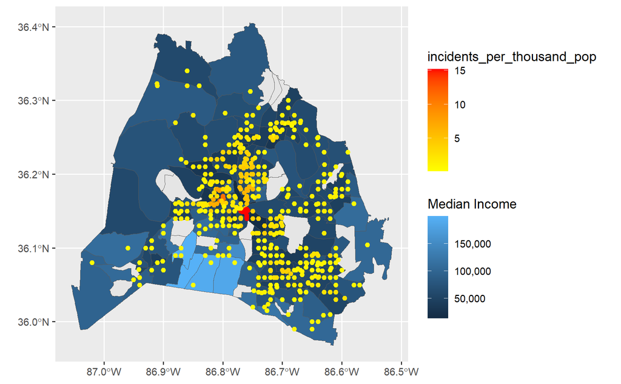

```r
ggplot() +
  geom_sf(data = DC) +
  geom_sf(data = burglaries_full_calc, aes(geometry = geometry.y, fill=median_income)) +
  scale_fill_continuous(labels=label_comma()) +
  labs(fill = "Median Income") +
  geom_sf(data = burglaries_full_calc, aes(geometry = geometry.x, color = incidents_per_thousand_pop)) +
  scale_color_gradient(low = "yellow", high = "red")
```

We’re interested in the relationship between median income and number of aggravated burglaries, so examine those variables on their own and together to see what you can find. You may want to perform additional calculations, create plots, etc.

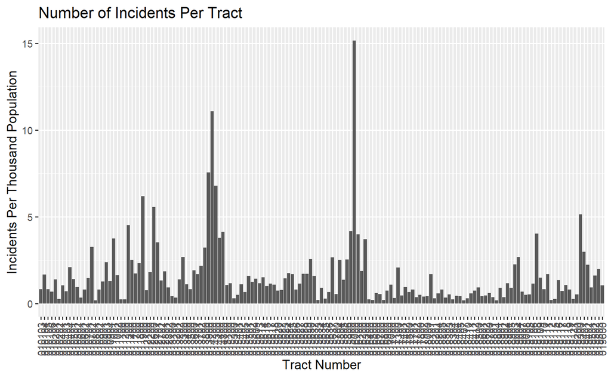

```r
incidents_per_thousand %>%
  ggplot(aes(x = tract, y = incidents_per_thousand_pop)) +
  geom_col(position = "dodge") +
  labs(x = "Tract Number", y = "Incidents Per Thousand Population", title = "Number of Incidents Per Tract") +
  theme(axis.text.x = element_text(angle = 90, vjust = 0.5, hjust=1))
```

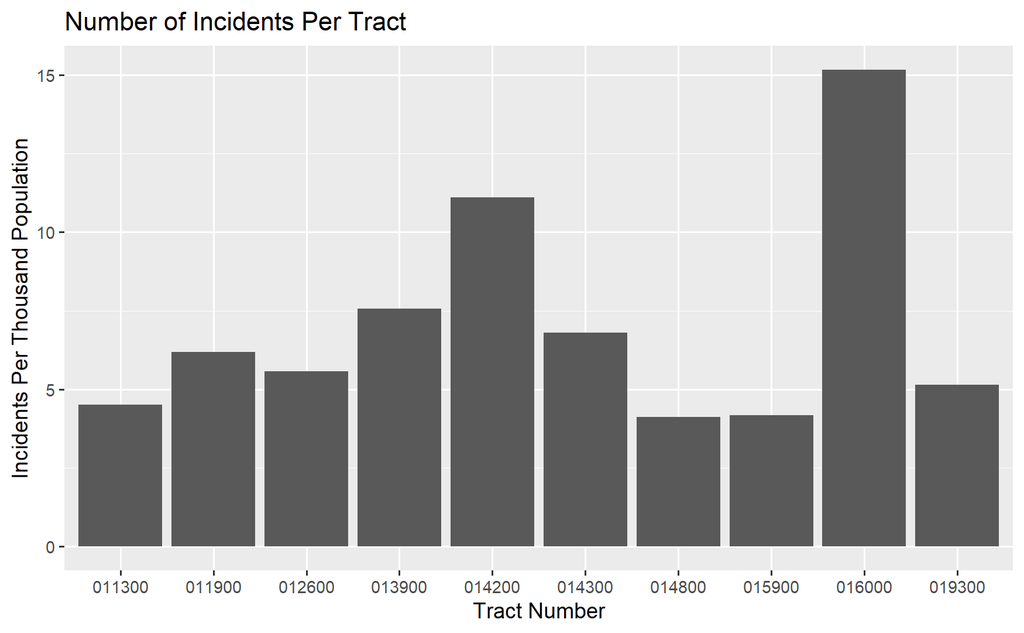

```r
incidents_per_thousand_top10 %>%
  ggplot(aes(x = tract, y = incidents_per_thousand_pop)) +
  geom_col() +
  labs(x = "Tract Number", y = "Incidents Per Thousand Population", title = "Number of Incidents Per Tract")
```

```r
burglaries_full %>%
  st_drop_geometry() %>%
  count(offense_description)
```

| offense_description | n |
| --- | --- |
| BURGLARY - AGGRAVATED | 415 |
| BURGLARY - AGGRAVATED - ACTING IN CONCERT | 5 |
| BURGLARY - ESPECIALLY AGGRAVATED | 12 |
| BURGLARY- AGGRAVATED | 710 |

```r
tract_income <- burglaries_full %>%
  st_drop_geometry() %>%
  select(c(tract,median_income)) %>%
  distinct()

incidents_per_tract_income <- inner_join(incidents_per_thousand,tract_income, by="tract") %>%
  arrange(desc(num_incidents_per_tract))
incidents_per_tract_income
```

| tract | num_incidents_per_tract | population | incidents_per_thousand_pop | median_income |
| --- | --- | --- | --- | --- |
| 016000 | 39 | 2570 | 15.1750973 | 21868 |
| 011300 | 27 | 5980 | 4.5150502 | 59107 |
| 011001 | 26 | 6912 | 3.7615741 | 50884 |
| 014200 | 23 | 2072 | 11.1003861 | 24237 |
| 019300 | 18 | 3498 | 5.1457976 | 18387 |
| 012701 | 18 | 5097 | 3.5314891 | 39033 |
| 011900 | 17 | 2746 | 6.1908230 | 51875 |
| 010903 | 15 | 6301 | 2.3805745 | 43354 |
| 019108 | 14 | 3478 | 4.0253019 | 34893 |
| 013900 | 13 | 1720 | 7.5581395 | 34741 |

[output cut: 145 more lines]

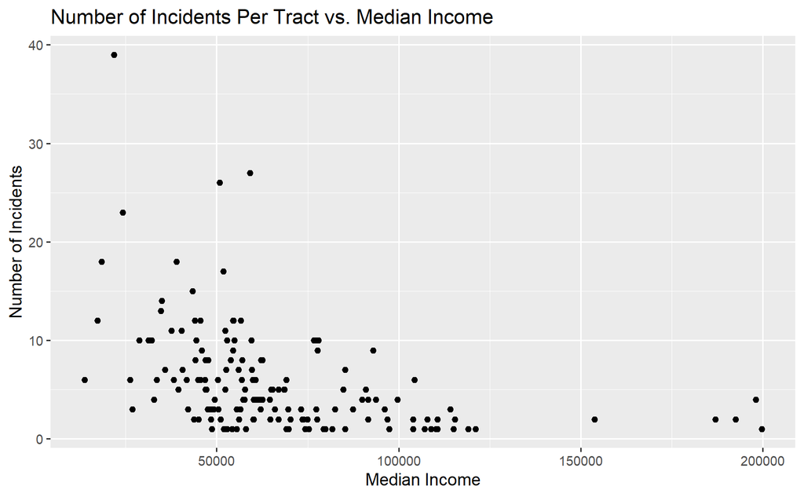

```r
incidents_per_tract_income %>%
  ggplot(aes(x = median_income, y = num_incidents_per_tract)) +
  geom_point() +
  labs(x = "Median Income", y = "Number of Incidents", title = "Number of Incidents Per Tract vs. Median Income")
```

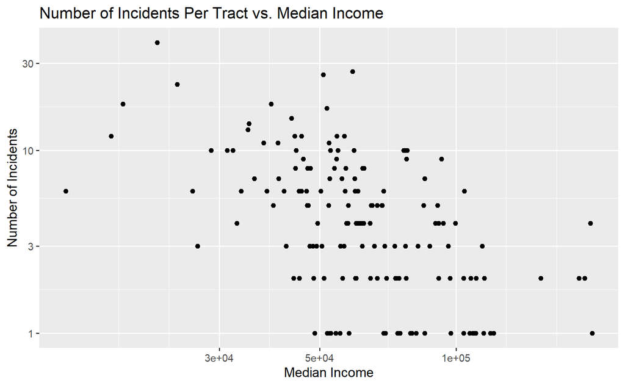

```r
incidents_per_tract_income %>%
  ggplot(aes(x = median_income, y = num_incidents_per_tract)) +
  geom_point() +
  scale_x_log10() +
  scale_y_log10() +
  labs(x = "Median Income", y = "Number of Incidents", title = "Number of Incidents Per Tract vs. Median Income")
```

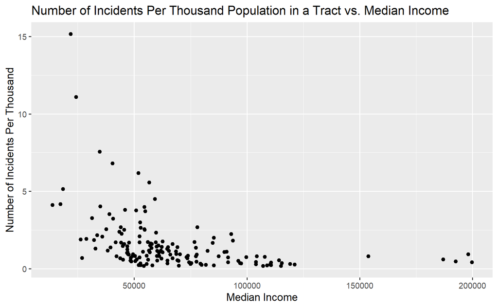

```r
incidents_per_tract_income %>%
  ggplot(aes(x = median_income, y = incidents_per_thousand_pop)) +
  geom_point() +
  labs(x = "Median Income", y = "Number of Incidents Per Thousand", title = "Number of Incidents Per Thousand Population in a Tract vs. Median Income")
```

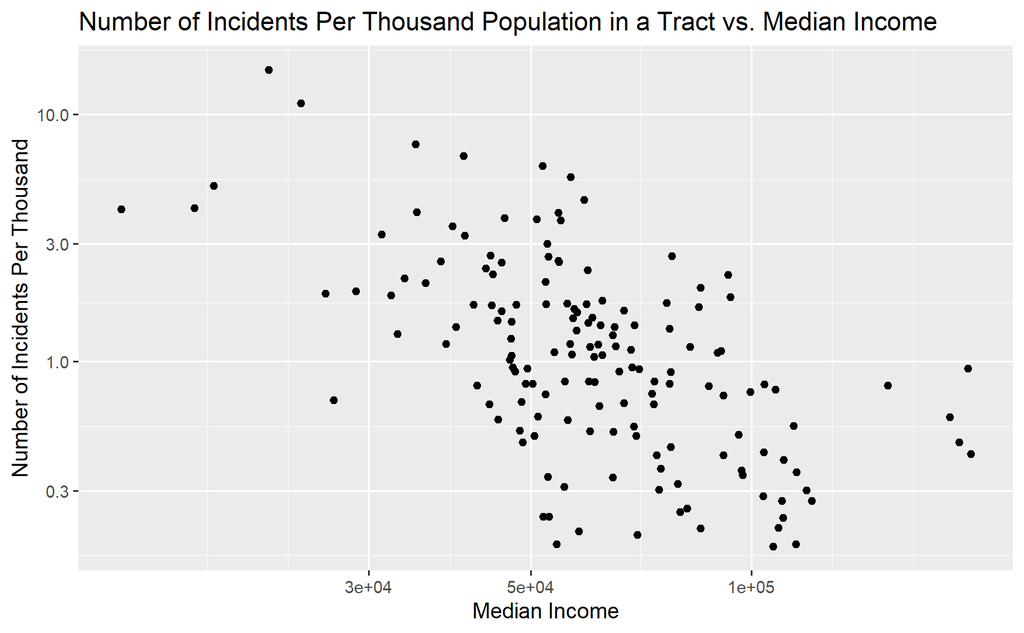

```r
incidents_per_tract_income %>%
  ggplot(aes(x = median_income, y = incidents_per_thousand_pop)) +
  geom_point() +
  scale_x_log10() +
  scale_y_log10() +
  labs(x = "Median Income", y = "Number of Incidents Per Thousand", title = "Number of Incidents Per Thousand Population in a Tract vs. Median Income")
```

```r
log10_incidents_df <- incidents_per_tract_income %>%
  mutate(log10_median_income = log10(median_income),
           log10_incidents_per_thousand_pop = log10(incidents_per_thousand_pop),
           log10_num_incidents_per_tract = log10(num_incidents_per_tract))

log10_incidents_df %>%
  select(log10_num_incidents_per_tract, log10_incidents_per_thousand_pop, log10_median_income) %>%
  cor()
```

```
                                 log10_num_incidents_per_tract
log10_num_incidents_per_tract                        1.0000000
log10_incidents_per_thousand_pop                     0.9251061
log10_median_income                                 -0.5340452
                                 log10_incidents_per_thousand_pop log10_median_income
log10_num_incidents_per_tract                           0.9251061          -0.5340452
log10_incidents_per_thousand_pop                        1.0000000          -0.5819588
log10_median_income                                    -0.5819588           1.0000000
```

Part 3 - Statistical Modeling Fit a Poisson regression model with target variable the rate of burglaries per census tract and with predictor the median income. Offset using the log of the population so that we are looking at the rate of burglaries per population instead of the number of burglaries. How can you interpret the meaning of the output? How do the estimates from the model compare to the observed data?

```r
pr_incidents_per_tract_income_const <- glm('num_incidents_per_tract ~ 1',
               data = incidents_per_tract_income,
               family = poisson)
summary(pr_incidents_per_tract_income_const)
```

```
Call:
glm(formula = "num_incidents_per_tract ~ 1", family = poisson,
    data = incidents_per_tract_income)

Coefficients:
            Estimate Std. Error z value Pr(>|z|)
(Intercept)  1.74442    0.03358   51.95   <2e-16 ***
---
Signif. codes:  0 ‘***’ 0.001 ‘**’ 0.01 ‘*’ 0.05 ‘.’ 0.1 ‘ ’ 1

(Dispersion parameter for poisson family taken to be 1)

    Null deviance: 611.5  on 154  degrees of freedom
Residual deviance: 611.5  on 154  degrees of freedom
AIC: 1121.3

Number of Fisher Scoring iterations: 5
```

```r
pr_incidents_income <- glm('num_incidents_per_tract ~ median_income',
               data = incidents_per_tract_income,
               family = poisson,
               offset = log(population))
summary(pr_incidents_income)
```

```
Call:
glm(formula = "num_incidents_per_tract ~ median_income", family = poisson,
    data = incidents_per_tract_income, offset = log(population))

Coefficients:
                Estimate Std. Error z value Pr(>|z|)
(Intercept)   -5.230e+00  9.688e-02  -53.99   <2e-16 ***
median_income -2.231e-05  1.669e-06  -13.37   <2e-16 ***
---
Signif. codes:  0 ‘***’ 0.001 ‘**’ 0.01 ‘*’ 0.05 ‘.’ 0.1 ‘ ’ 1

(Dispersion parameter for poisson family taken to be 1)

    Null deviance: 688.98  on 154  degrees of freedom
Residual deviance: 464.41  on 153  degrees of freedom
AIC: 976.24

Number of Fisher Scoring iterations: 5
```

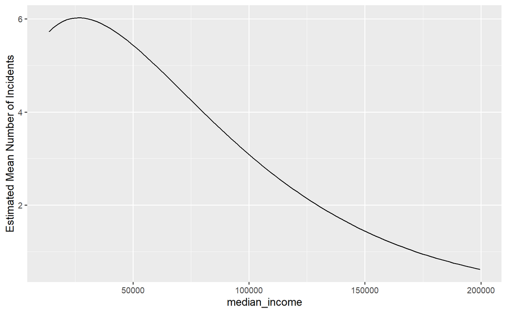

```r
est_df <- tibble(
  median_income = seq(from = min(incidents_per_tract_income$median_income, na.rm = TRUE),
                          to = max(incidents_per_tract_income$median_income, na.rm = TRUE),
                          length.out = 100),
  population = seq(from = min(incidents_per_tract_income$population, na.rm = TRUE),
                          to = max(incidents_per_tract_income$population, na.rm = TRUE),
                          length.out = 100),    )

est_df <- est_df %>%
  bind_cols(predict(pr_incidents_income, newdata = est_df, type = "response")) %>%
  rename("Estimated Mean Number of Incidents" = "...3")
est_df %>%
  ggplot(aes(x = median_income, y = `Estimated Mean Number of Incidents`)) +
  geom_line()
```

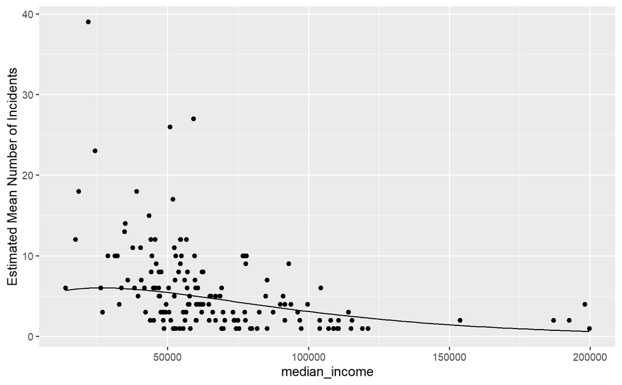

```r
ggplot(est_df) +
  geom_line(aes(x = median_income, y = `Estimated Mean Number of Incidents`)) +
  geom_point(data = incidents_per_tract_income, aes(x=median_income, y=num_incidents_per_tract))
```

```r
NA
```

[output not shown]